# ATDS Project

José Pinto - up201603713

4/06/2021

# Introduction

This report is being created for the final and only project of the Advanced Topics in Data Science (ATDS) course. This project entails the usage of a Farfetch dataset, containing anonymized information about luxury fashion brand purchases, for the creation of a brand recommender system.

The objectives of this project encompass 3 different tasks.  
Task 1 - Data preprocessing and visualization.  
Task 2 - Recommender systems using popularity, association rules or collaborative filtering; using both ROC and precision-recall curves with top N of 1,2 and 6 for comparisons.  
Task 3 - Open ended task involving the improvement of results by employing contextual information other than user id and brand.

For task 1 almost no preprocessing was required, and as such, an extensive visualization process was undertaken. The table and plot outputs were, due to size, placed at the end of the report as an annex. In task 2 the set of recommender systems is created utilizing different data subsets of different dimensions and the results compared using cross-validation. An example for each model type for a single user is also presented. For task 3, an LSTM model was selected to employ the contextual information and attempt to improve results.

## Import Libraries

To make it easier to run and thus replicate attained results all required libraries are imported here and should be properly installed by the user before running. It is important to stress that the order in which the libraries are imported is relevant as there are some cases of function masking, which can cause problems when libraries are loading in a different order.

```r
library(keras)
library(tensorflow)
library(recommenderlab)
library(dplyr)
library(tidyr)
library(readr)
library(plotly)
library(e1071)
library(ggpubr)
library(ggplot2)
library(reshape2)
library(psych)
library(proxy)
library(groupdata2)
library(abind)
library(caret)
```

## Read Data

The first task that must be undertaken is the reading of the datasets from files into memory to allow further manipulation. Here relative paths are used, and it is assumed that the files are in the same directory as the markdown file. Of course, these paths can be changed by the user to load the dataset from wherever it would be most convenient.

Both files that were provided for this project are read, with the first one being user_brands, containing most of the information and the second one containing only the Farfetch created 120-dimensional brand embeddings. The contents of the second file will only be used in task 3.

```r
userBrandsTible = read_csv("users_brands.csv")
userBrandsDF = as.data.frame(userBrandsTible)
brandFeatures = read_csv("brand_features.csv")
```

# Task 1

Task 1 entails both the data visualization and preprocessing steps. An initial analysis of the contents led to the conclusion that no preprocessing steps are required for data visualization. And preprocessing required is problem dependent and is left for when it is required.

### Content Inspection

The first visualization task that was undertaken is the inspection of some data entries, not only to check the particular values and value formats but also the respective types and any possible anomalies in the loading process.

```r
head(userBrandsDF)
```

```
##                                                            user_id brand_id
## 1 65b4c425c57d4d5cd6a09b6721f76dfe76fca72000a58ad1b252ef4ba10dfb0d 92850413
## 2 e45ae0e683895ab429483c3aaeba836c9e6904692daebad297c5e370d735d6df 59833398
## 3 ab112830f538338e386af96be442ea1d9e81d76fabc17b16fffa8f98be478241 72430441
## 4 577321c8f3b5bff9e5470184606207ed04edc14a82f706a92e9fe62c998d2aba 29631653
## 5 75624f1d112034145f181fb895479093f94ea2a7de0e48d582609e35dcd89193 50327475
## 6 36e368697be4d8d37b94338581c0b963f99db8c2c0b508bf80e28ede94c18930 48210076
##   platform     country user_segment purchase_date perc_sale
## 1 35279833  country_76    segment_2           154       0.0
## 2 35279833 country_144    segment_1           114       0.0
## 3 35279833  country_35    segment_4           204  (25, 50]
## 4 82921252 country_177    segment_3           139  (25, 50]
## 5 35279833 country_125    segment_0           170       0.0
## 6 59713904  country_74    segment_2           174       0.0
```

```r
str(userBrandsDF)
```

```
## 'data.frame':    846490 obs. of  7 variables:
##  $ user_id      : chr  "65b4c425c57d4d5cd6a09b6721f76dfe76fca72000a58ad1b252ef4ba10dfb0d" "e45ae0e683895ab429483c3aaeba836c9e6904692daebad297c5e370d735d6df" "ab112830f538338e386af96be442ea1d9e81d76fabc17b16fffa8f98be478241" "577321c8f3b5bff9e5470184606207ed04edc14a82f706a92e9fe62c998d2aba" ...
##  $ brand_id     : num  92850413 59833398 72430441 29631653 50327475 ...
##  $ platform     : num  35279833 35279833 35279833 82921252 35279833 ...
##  $ country      : chr  "country_76" "country_144" "country_35" "country_177" ...
##  $ user_segment : chr  "segment_2" "segment_1" "segment_4" "segment_3" ...
##  $ purchase_date: num  154 114 204 139 170 174 172 142 161 139 ...
##  $ perc_sale    : chr  "0.0" "0.0" "(25, 50]" "(25, 50]" ...
##  - attr(*, "spec")=
##   .. cols(
##   ..   user_id = col_character(),
##   ..   brand_id = col_double(),
##   ..   platform = col_double(),
##   ..   country = col_character(),
##   ..   user_segment = col_character(),
##   ..   purchase_date = col_double(),
##   ..   perc_sale = col_character()
##   .. )
```

From this the first thing to note is the overall dataset shape, containing 846490 observations from 7 different variables.

By performing this analysis some important data facets were identified. The first is that, although some variables have numerical type, all but purchace_date are categorical in meaning, enforcing the need from special care on their investigation. Another important factor regards the values for user_id, which were encoded in a large string which can make results difficult to analyze individually. Finally, the last feature that is important to note is that perc_sale presents its values in the form of discount intervals.

### Statistical Moments

To better understand the overall data distributions an extensive statistical moment table was created, containing, among others, variable types, missing value counts, extremes, rages, quantiles, mean, mode, variance and number of unique values. Although, as most variables are categorical in nature, and as such these statistical moments have little meaning, they still provide important insight to the data.

```r
Mode <- function(x) {
  uniques <- unique(x)
  uniques[which.max(tabulate(match(x, uniques)))]
}

ModeCount <- function(x) {
  uniques <- unique(x)
  max(tabulate(match(x, uniques)))
}

userBrandsStatistics = data.frame(matrix(ncol = ncol(userBrandsDF), nrow = 0))
colnames(userBrandsStatistics) = colnames(userBrandsDF)
for (column in colnames(userBrandsDF)){
  columnData = pull(userBrandsDF,column)
  userBrandsStatistics["type",column] = mode(columnData)
  userBrandsStatistics["na count",column] = sum(is.na(columnData))
  userBrandsStatistics["min",column] = min(columnData)
  userBrandsStatistics["25 quantile",column] = tryCatch(
    {quantile(columnData, 0.25)},
    error = function(e) { return(NA) }
  )
  userBrandsStatistics["mean",column] = mean(columnData)
  userBrandsStatistics["median",column] = median(columnData)
  userBrandsStatistics["75 quantile",column] = tryCatch(
    {quantile(columnData, 0.75)},
    error = function(e) { return(NA) }
  )
  userBrandsStatistics["max",column] = max(columnData)
  userBrandsStatistics["range",column] = tryCatch(
    {as.numeric(userBrandsStatistics["max",column])- as.numeric(userBrandsStatistics["min",column])},
    error = function(e) { return(NA) }
  )
  userBrandsStatistics["IQR",column] = tryCatch(
    {as.numeric(userBrandsStatistics["75quantile",column])- as.numeric(userBrandsStatistics["25quantile",column])},
    error = function(e) { return(NA) }
  )
  userBrandsStatistics["sd",column] = sd(columnData)
  userBrandsStatistics["var",column] = var(columnData)
  userBrandsStatistics["coef var",column] = as.numeric(userBrandsStatistics["sd",column]) / as.numeric(userBrandsStatistics["mean",column])
  userBrandsStatistics["skewness",column] = tryCatch(
    {skewness(columnData)},
    error = function(e) { return(NA) }
  )
  userBrandsStatistics["kurtosis",column] = tryCatch(
    {kurtosis(columnData)},
    error = function(e) { return(NA) }
  )
  userBrandsStatistics["mode",column] = Mode(columnData)
  userBrandsStatistics["mode count",column] = ModeCount(columnData)
  userBrandsStatistics["unique count",column] = length(unique(columnData))
  userBrandsStatistics["sum",column] = tryCatch(
    {sum(columnData)},
    error = function(e) { return(NA) }
  )
}
userBrandsStatistics
```

```
##                                                                       user_id
## type                                                                character
## na count                                                                    0
## min          00001fb7f8a0bab989afb3b2e3f87091f19c624f4c918f5e1fbb3c2ee12e9db6
## 25 quantile                                                              <NA>
## mean                                                                     <NA>
## median                                                                   <NA>
## 75 quantile                                                              <NA>
## max          ffffede449ad3486ffee78949e0d34db24c36de30f71e1a20182df8d658281a2
## range                                                                    <NA>
## IQR                                                                      <NA>
## sd                                                                       <NA>
## var                                                                      <NA>
## coef var                                                                 <NA>
## skewness                                                                 <NA>
## kurtosis                                                                 <NA>
## mode         e646f8406d203c00922016d163433c7665bdd4d3b6260e72626a2900c7910727
## mode count                                                                 24
## unique count                                                           329213
## sum                                                                      <NA>
##                         brand_id          platform     country user_segment
## type                     numeric           numeric   character    character
## na count                       0                 0           0            0
## min                       102532          15766995   country_0    segment_0
## 25 quantile             27968276          35279833        <NA>         <NA>
## mean            52775913.8391416  47381156.6653605        <NA>         <NA>
## median                  51215738          39857033        <NA>         <NA>
## 75 quantile             80735391          59713904        <NA>         <NA>
## max                     99855154          96462699  country_99    segment_5
## range                   99752622          80695704        <NA>         <NA>
## IQR                         <NA>              <NA>        <NA>         <NA>
## sd              29031126.4920308  13546980.7862736        <NA>         <NA>
## var              842806305396293   183520688423666        <NA>         <NA>
## coef var       0.550082876452244 0.285914944667815        <NA>         <NA>
## skewness     0.00453599969320028 0.559633782166231        <NA>         <NA>
## kurtosis       -1.25236279783164 -0.64813779627103        <NA>         <NA>
## mode                    89083147          35279833 country_118    segment_1
## mode count                 23022            379237      189617       355539
## unique count                1771                12         175            6
## sum               44674283305695    40107675305661        <NA>         <NA>
##                   purchase_date perc_sale
## type                    numeric character
## na count                      0         0
## min                           1   (0, 25]
## 25 quantile                  67      <NA>
## mean           119.200774964855      <NA>
## median                      129      <NA>
## 75 quantile                 170      <NA>
## max                         231       0.0
## range                       230      <NA>
## IQR                        <NA>      <NA>
## sd             64.4743898286592      <NA>
## var            4156.94694377791      <NA>
## coef var      0.540889015592967      <NA>
## skewness     -0.169298217417195      <NA>
## kurtosis      -1.10177341210125      <NA>
## mode                        161       0.0
## mode count                14798    383519
## unique count                231         5
## sum                   100902264      <NA>
```

The most important takeaways from this large table are as follows:

For user_id the most common value only appears 24 times, while there are 329213 unique values for less than 3 times as many observations. This leads to the conclusion that the dataset is extremely sparce and special care will have to be had in its analysis.

For brand_id the mode if far more common, with 23022 appearances, being as such very well represented. With 1771 unique values there is much less sparsity than for user_id, although is still large enough for an individual analysis to be unreasonable.

From this point although an individual analysis could be done for each other variables, the conclusions are almost identical to those for brand_id. The only important remark to make is that the variables platform, user_segment and perc_sale have a low enough number of unique values to warrant an individual value analysis.

### Unique Value Analysis

With this in mind, the unique values for these 3 variables were obtained and studied. From this it was possible to see that the values for platform and user_segment are not meaningful, being only randomly assigned ids. Perc_sale, one the other hand, shows 5 values, 4 of which are 25% sale intervals (25% to 50%, 75% to 100%, etc.) and the last, with value 0, indicates no discount. This suggests that perc_sale is ordinal, and as such could be label encoded with little loss of meaning.

```r
print(unique(userBrandsDF$platform))
```

```
##  [1] 35279833 82921252 59713904 39857033 50298854 34959346 24380949 54454273
##  [9] 15766995 22734142 47514527 96462699
```

```r
print(unique(userBrandsDF$user_segment))
```

```
## [1] "segment_2" "segment_1" "segment_4" "segment_3" "segment_0" "segment_5"
```

```r
print(unique(userBrandsDF$perc_sale))
```

```
## [1] "0.0"       "(25, 50]"  "(0, 25]"   "(50, 75]"  "(75, 100]"
```

To finalize the set of data statistical moments, a second table containing moments that should be more meaningful for categorical variables was created. For this table, instead of utilizing the values themselves, the number of occurrences per unique value is employed.

```r
uniqueStatistics = data.frame(matrix(ncol = ncol(userBrandsDF), nrow = 0))
colnames(uniqueStatistics) = colnames(userBrandsDF)
for (column in colnames(userBrandsDF)){
  columnData = (userBrandsDF %>% group_by_at(column) %>% tally())$n
  uniqueStatistics["type",column] = mode(columnData)
  uniqueStatistics["count",column] = length(columnData)
  uniqueStatistics["na count",column] = sum(is.na(columnData))
  uniqueStatistics["min",column] = min(columnData)
  uniqueStatistics["25 quantile",column] = tryCatch(
    {quantile(columnData, 0.25)},
    error = function(e) { return(NA) }
  )
  uniqueStatistics["mean",column] = mean(columnData)
  uniqueStatistics["median",column] = median(columnData)
  uniqueStatistics["75 quantile",column] = tryCatch(
    {quantile(columnData, 0.75)},
    error = function(e) { return(NA) }
  )
  uniqueStatistics["max",column] = max(columnData)
  uniqueStatistics["range",column] = tryCatch(
    {as.numeric(uniqueStatistics["max",column])- as.numeric(uniqueStatistics["min",column])},
    error = function(e) { return(NA) }
  )
  uniqueStatistics["IQR",column] = tryCatch(
    {as.numeric(uniqueStatistics["75 quantile",column]) - as.numeric(uniqueStatistics["25 quantile",column])},
    error = function(e) { return(NA) }
  )
  uniqueStatistics["sd",column] = sd(columnData)
  uniqueStatistics["var",column] = var(columnData)
  uniqueStatistics["coef var",column] = as.numeric(uniqueStatistics["sd",column]) / as.numeric(uniqueStatistics["mean",column])
  uniqueStatistics["skewness",column] = tryCatch(
    {skewness(columnData)},
    error = function(e) { return(NA) }
  )
  uniqueStatistics["kurtosis",column] = tryCatch(
    {kurtosis(columnData)},
    error = function(e) { return(NA) }
  )
  uniqueStatistics["mode",column] = Mode(columnData)
  uniqueStatistics["mode count",column] = ModeCount(columnData)
  uniqueStatistics["unique count",column] = length(unique(columnData))
}
print(uniqueStatistics)
```

```
##                       user_id         brand_id          platform
## type                  numeric          numeric           numeric
## count                  329213             1771                12
## na count                    0                0                 0
## min                         1                1                 3
## 25 quantile                 1               14            376.25
## mean         2.57125326156622 477.972896668549  70540.8333333333
## median                      2               57             12824
## 75 quantile                 3              229           34408.5
## max                        24            23022            379237
## range                      23            23021            379234
## IQR                         2              215          34032.25
## sd           2.33704794337009  1726.6482940855  136023.169010974
## var          5.46179308961037 2981314.33146838  18502302507.7879
## coef var     0.90891394414665 3.61243975572708  1.92828979448273
## skewness     2.69042099494101 7.72615321730558    1.544551106458
## kurtosis     9.35063859226698 72.5998431649631 0.527163457775885
## mode                        1                1                 3
## mode count             132091               75                 2
## unique count               24              585                11
##                       country      user_segment     purchase_date
## type                  numeric           numeric           numeric
## count                     175                 6               231
## na count                    0                 0                 0
## min                         1             42100              1982
## 25 quantile                 9           55811.5            2860.5
## mean         4837.08571428571  141081.666666667  3664.45887445887
## median                    122          118175.5              3379
## 75 quantile              2147         162651.25              4157
## max                    189617            355539             14798
## range                  189616            313439             12816
## IQR                      2138         106839.75            1296.5
## sd           17755.2890066876  117286.073484735  1320.66591463699
## var          315250287.711002  13756023033.4667  1744158.45808395
## coef var     3.67065833757083 0.831334618138913 0.360398618153959
## skewness     7.47568085149853 0.813596576523874  3.65298340534392
## kurtosis     68.0561319345571 -0.97206332327874  23.3827130959389
## mode                        1             46523              4029
## mode count                  9                 1                 2
## unique count              127                 6               227
##                      perc_sale
## type                   numeric
## count                        5
## na count                     0
## min                        908
## 25 quantile              48699
## mean                    169298
## median                   91704
## 75 quantile             321660
## max                     383519
## range                   382611
## IQR                     272961
## sd            171773.801569098
## var              29506238905.5
## coef var      1.01462392685736
## skewness     0.251431661408326
## kurtosis     -2.15079936814689
## mode                     91704
## mode count                   1
## unique count                 5
```

At a first glance it is immediately obvious that the results which were obtained are far more helpful. From this table, the obtained conclusions were as follows:

Both platform and country show similar results to the ones presented before, thus making separate analysis for each of these variable’s values redundant and undesirable.

User_segment, on the other hand, has a distribution relatively close to normal, and with the most infrequent value appearing 42100 times, an analysis per segment would be reasonable.

With purchace_date being the only numerical variable, this analysis does not add much. It is furthermore not reasonable to make a model per date, regardless of the number of occurrences, since we would expect a recommender system to work on different, later dates.

Finally, perc_sale shows a surprising result given the very low number of unique values. This is the fact that the least common value only appears 908 times. Nevertheless, disregarding this, the variable presents a mostly centered distribution.

### Distributions

The different statistical summary tables previously analyzed provided a great deal of insight into the dataset. Despite this, due to the aggregation of information into a set of single values a lot of detail is lost. Taking this into consideration the following step involves the further study of variable distributions aided by a large set of graphical plots. This set of plots is comprised of bar plots, histograms, boxplots, normal Q-Q plots, pie plots and a line chart.

#### Bar Plots

Given the mostly categorical nature of the data, one of the most important plot types is the bar plot, for which all available variables are applicable, even if not necessarily very compatible. With the intent of making these understandable, a maximum of 50 different classes/values is displayed at a time, which has as a downside not giving a full overview of the data. The most important takeaways from these plots are:

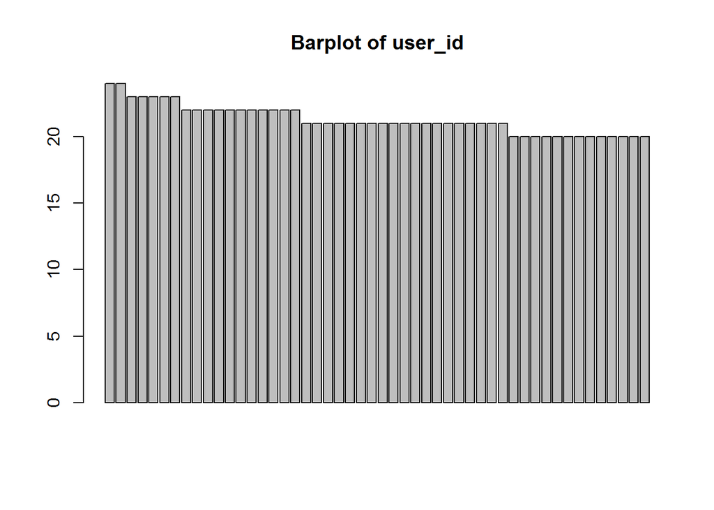

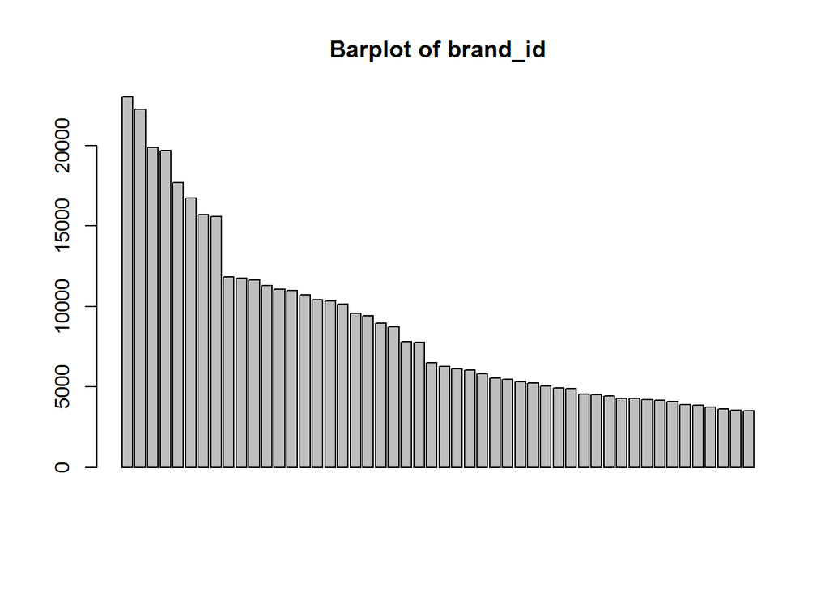

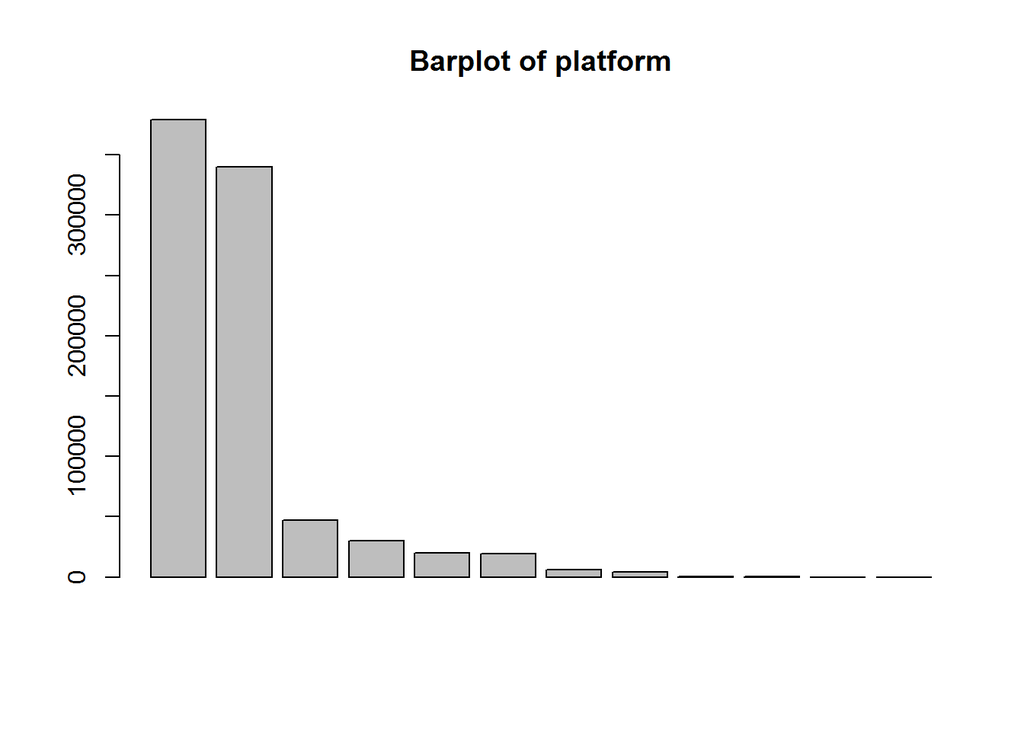

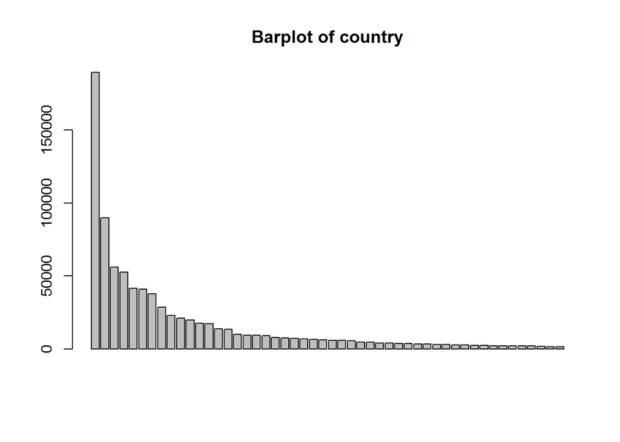

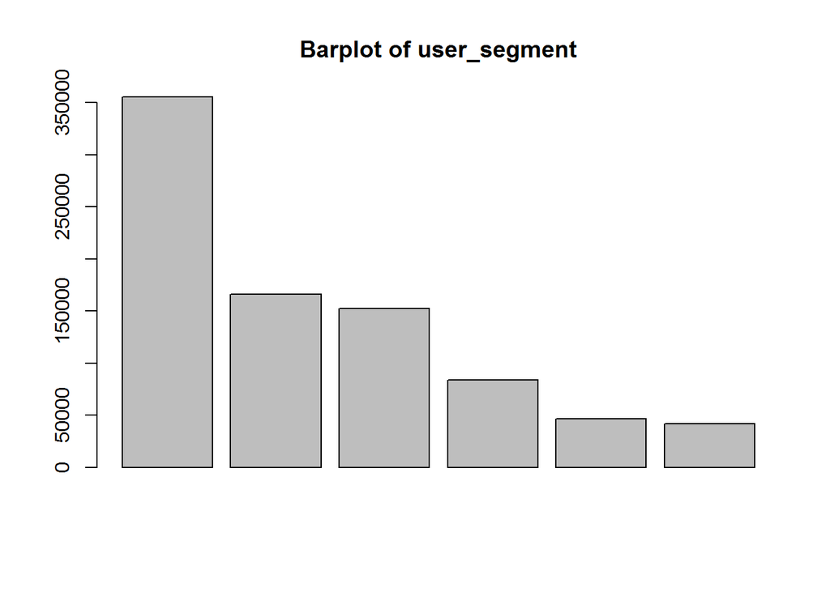

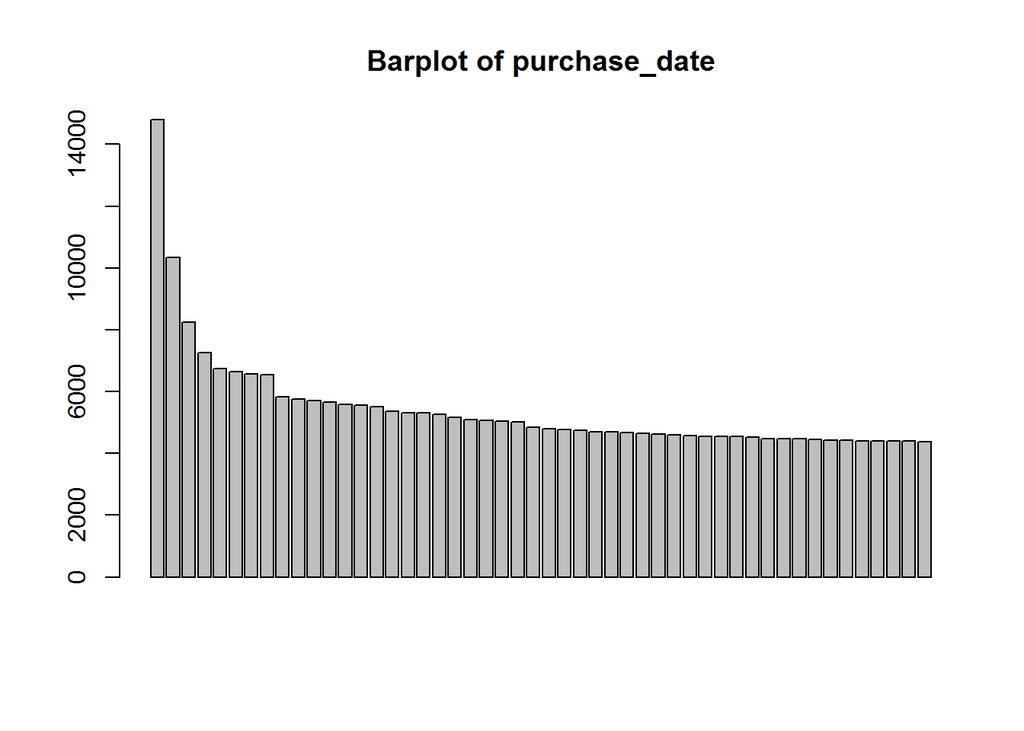

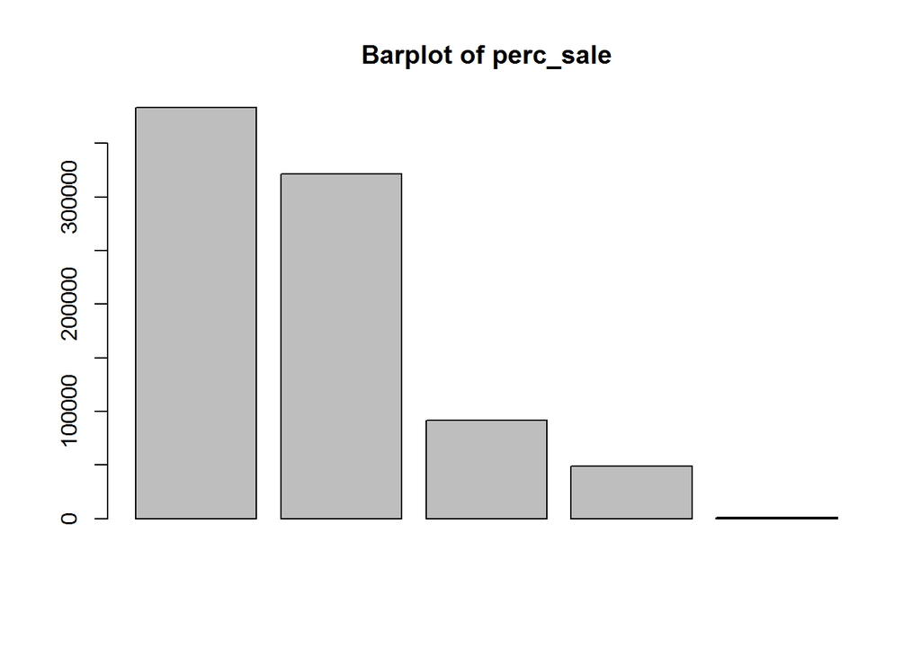

```r
for (column in colnames(userBrandsDF)){
  columnData = pull(userBrandsDF,column)
  t = table(columnData)
  barplot(
    sort(t, decreasing=TRUE)[1:min(length(unique(columnData)),50)],
    xaxt = "n", main=paste("Barplot of",column)
  )
}
```

From the bar plot of user_id, despite only a minimal number of values being shown it can be clearly be seen that the higher the value the less frequent it is. It is easy to imagine this plot going through all values, with a longer and longer tail.

For brand_id a different story is told, with only a few very common brands that overshadow the vast majority. This of course, means that only a minority of brands is properly represented, with all others lacking in terms of information.

This is even more noticeable for the platform variable, with 2 platforms having each more prevalence than all others combined.

The same is repeated for the variable country, with one being by far the most prevalent. Upon a quick search it was concluded that this is likely the USA, with the second highest being the UK.

Finally, perc_sale has two values that are by far the most common and one which barely appears. A further analysis of this was performed, which will be detailed further along the visualization process.

#### Histograms

After bar plots the creation of histograms for all applicable variables proceeded. Given the existence of only one numerical variable, and it being related to time, which usually does not give much insight on its own, these plots were expected not be very useful, which was confirmed. Thus, not a lot of insight is gained from this alone. Nevertheless, they were kept for completeness of the process.

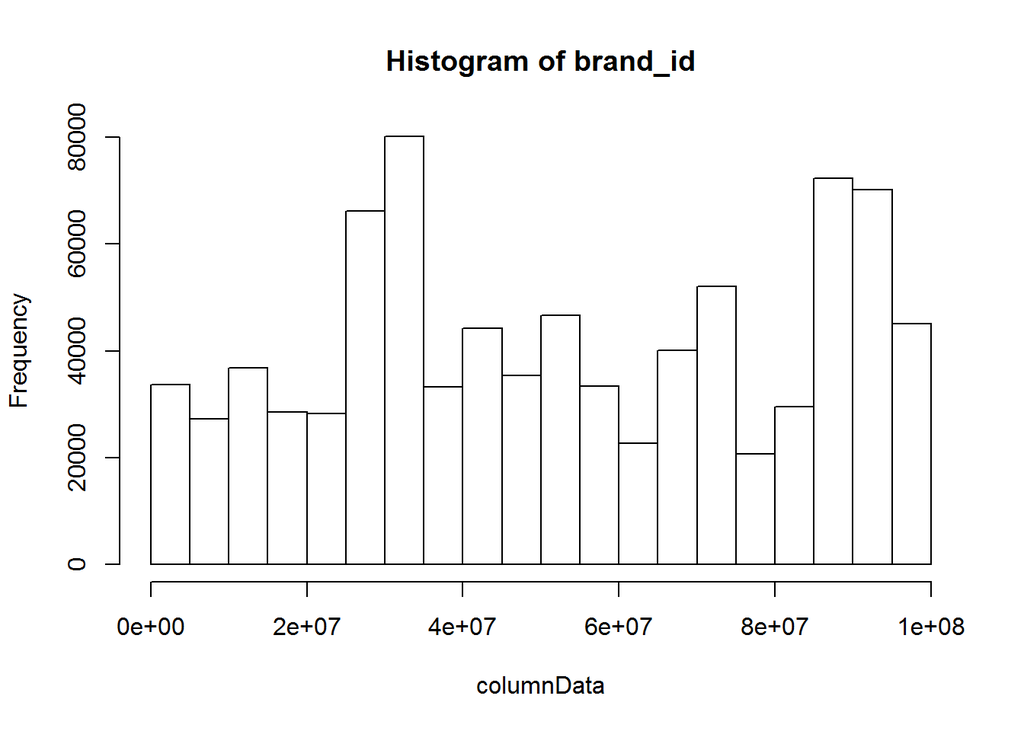

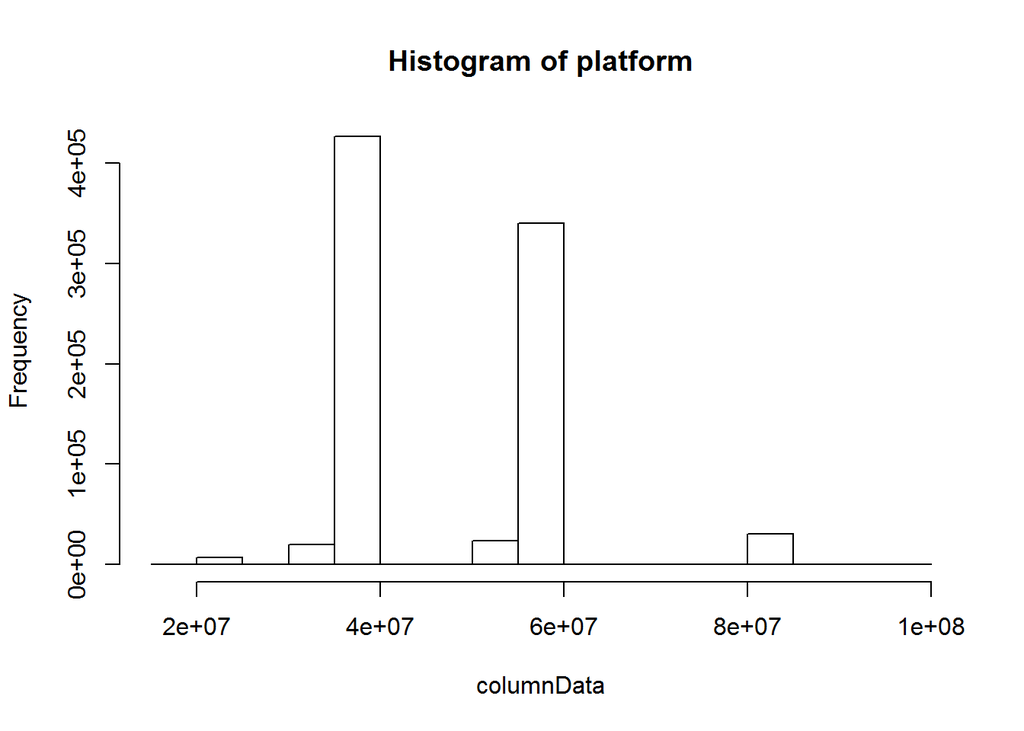

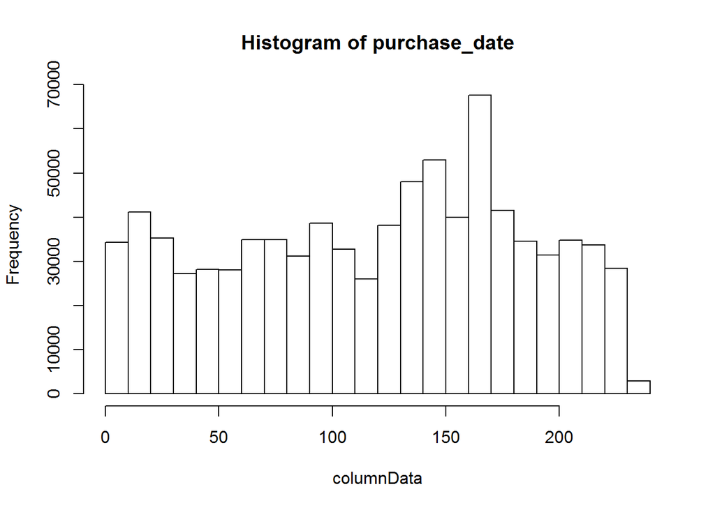

```r
for (column in colnames(userBrandsDF)){
  columnData = pull(userBrandsDF,column)
  tryCatch(
    {
      hist(columnData, main=paste("Histogram of",column))
    },
    error = function(e) {}
  )
}
```

#### Box Plots

Box plots followed the histograms, but once again being mostly a tool for analysis of numerical variables they presented little in the way of new information. Once again, they were, nevertheless, kept.

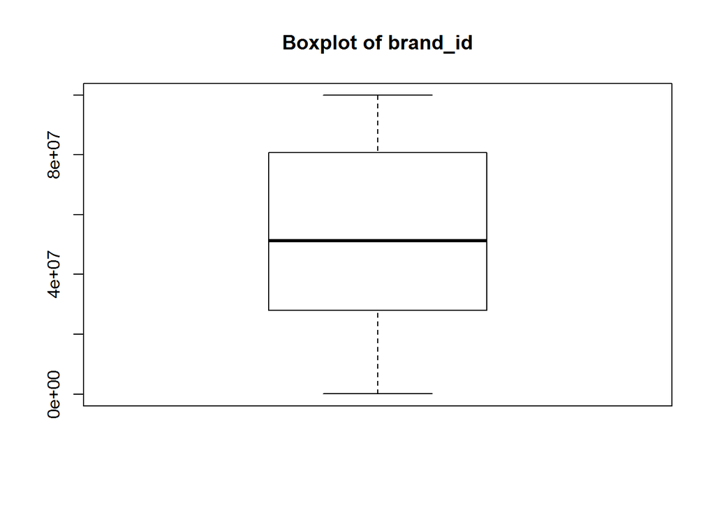

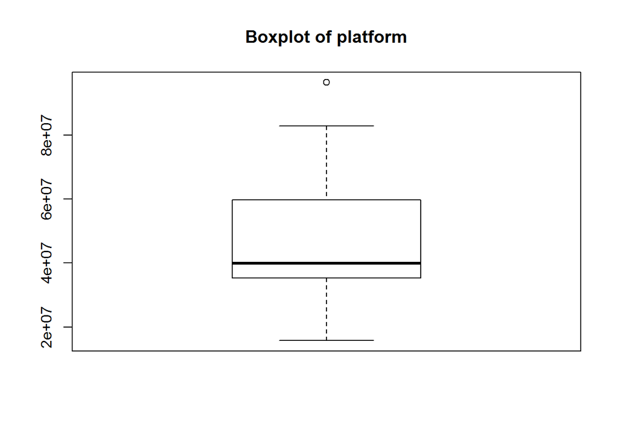

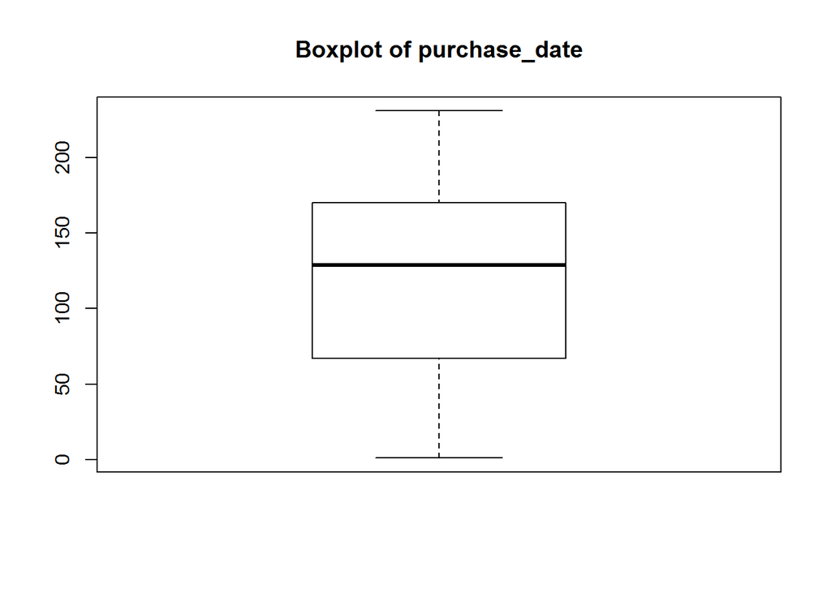

```r
for (column in colnames(userBrandsDF)){
  columnData = pull(userBrandsDF,column)
  tryCatch(
    {
      boxplot(columnData, main=paste("Boxplot of",column))
    },
    error = function(e) {}
  )
}
```

#### Q-Q Plots

To verify the conclusions regarding the normality of the different variables a set of Q-Q plots was created. Despite many different attempts, due to the length of time it takes for the plots to be generated, Rmarkdown does not plot them. As such, to observe them they must be done in the command line. Therefore, in this case the images are loaded from a file.

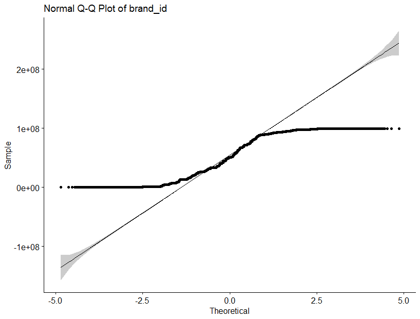

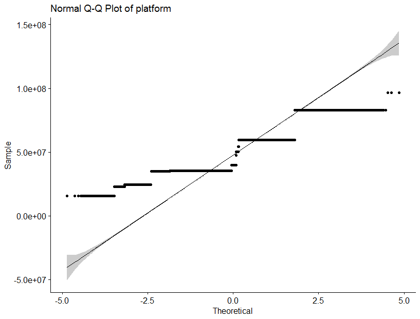

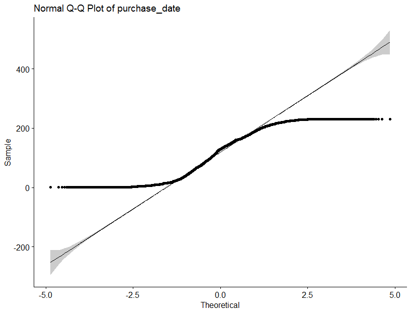

```r
for (column in colnames(userBrandsDF)){
  columnData = pull(userBrandsDF,column)
  t = table(columnData)
  tryCatch(
    {
      ggqqplot(userBrandsDF,x=column, main=paste("Normal Q-Q Plot of",column))
    },
    error = function(e) {print(column)}
  )
}
```

From the analysis of these plots, it was verified that most of points fall outside the confidence bands, and as such it becomes obvious that the data is, in fact, not normally distributed.

#### Pie Charts

The pie chart is a tool that is often ignored or even discouraged in a data visualization pipeline, with more importance given to the bar plot. However, is this case, due to the overly large number of unique categorical values and the heavy left skewness of variable frequencies, the pie chart can be very useful for a brief and informative plot.

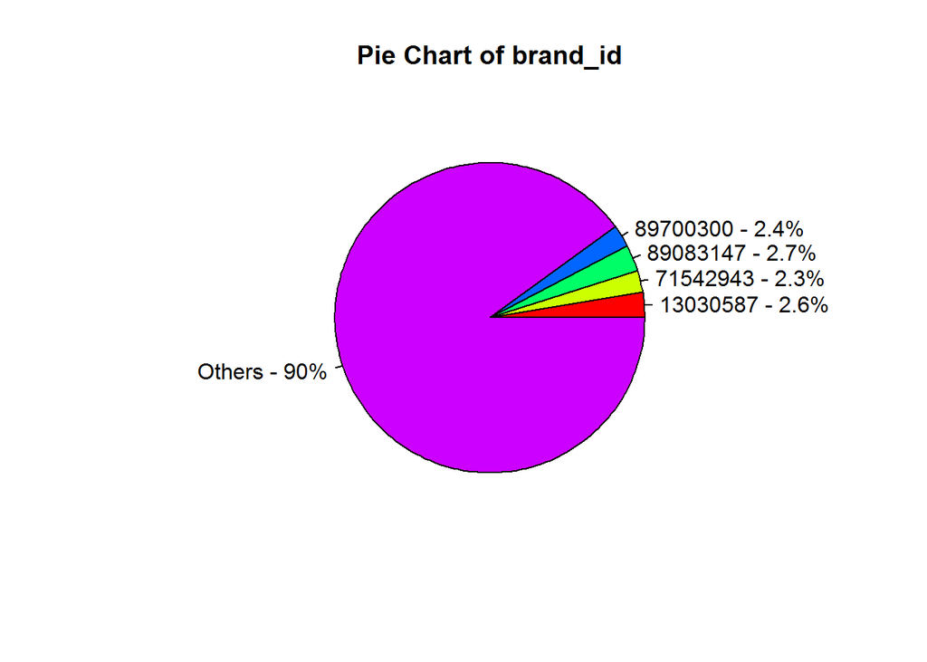

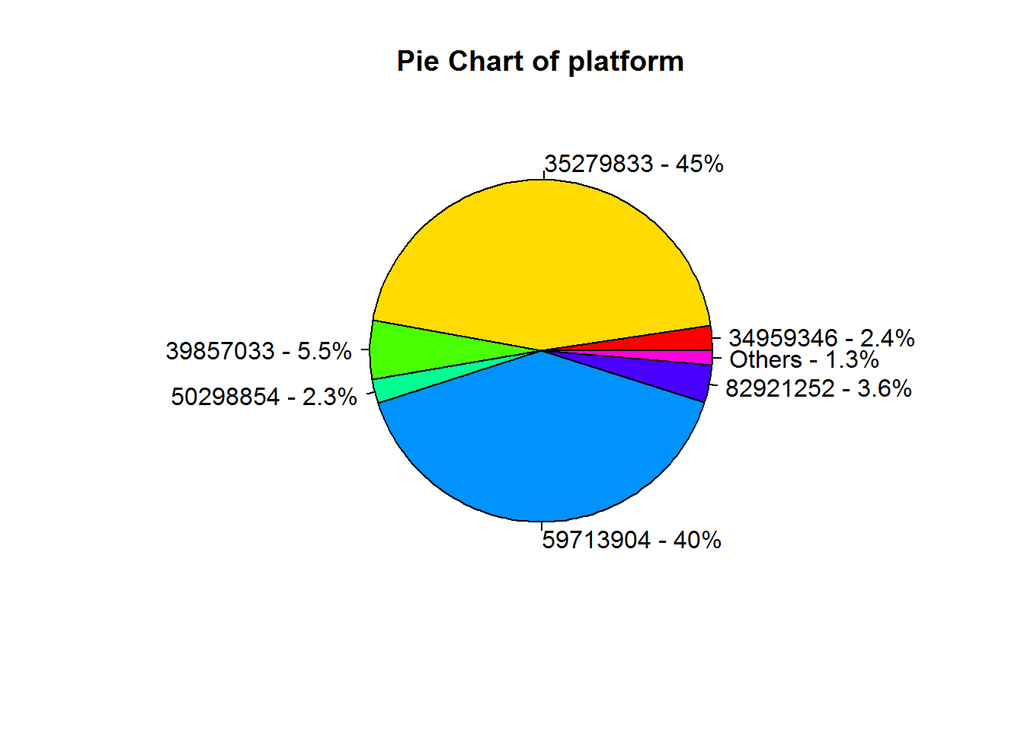

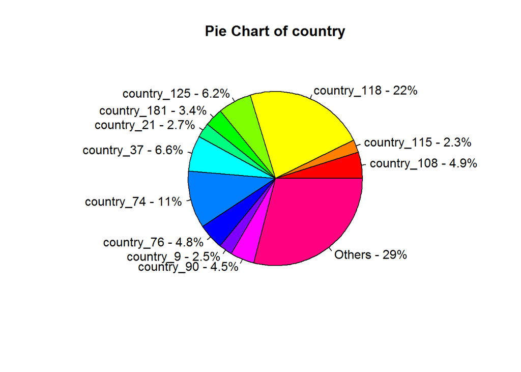

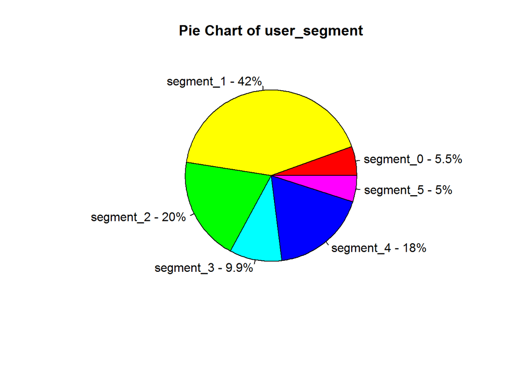

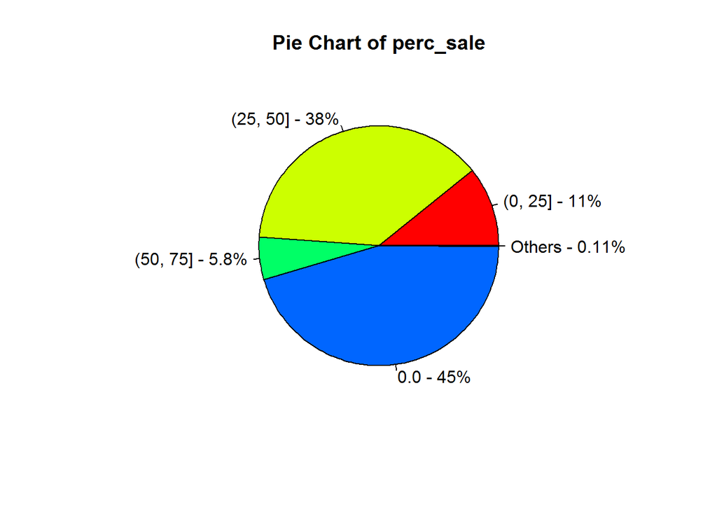

```r
for (column in colnames(userBrandsDF)){
  columnData = pull(userBrandsDF,column)
  t = table(columnData)
  theshold = 2.1
  relFreq = as.integer(t)/sum(t)*100
  if (length(which(relFreq<=theshold))>0){
    slices = c(
      relFreq[which(relFreq>theshold)],
      sum(relFreq[which(relFreq<=theshold)])
    )
    labels = c(
      names(t)[which(relFreq>theshold)],
      "Others"
    )
  }
  else{
    slices = relFreq
    labels = names(t)
  }
  if (length(slices)>=2){
    labels <- paste(labels, signif(slices,2), sep=" - ") # add percents to labels
    labels <- paste(labels,"%",sep="") # ad % to labels
    pie(
      slices,labels = labels,
      col=rainbow(length(labels)),
      main=paste("Pie Chart of",column)
    )
  }
}
```

For the creation of the pie charts, any variable whose occurrence is less than 2.1% is combined into the “other” slice, while if there are less than 2 slices after the process, the plot is skipped. The important information obtained from this set of plots is as follows:

The chart of brand_id shows that there are 4 brands that dominate. These, nevertheless, only account for 10% of the total entries.

For platform there are 2 very common values, with others having roughly the same amount of participation.

The third pie chart of country shows a more diverse distribution, with 11 total countries having more than 2% participation. This however means that the remaining 164 account for only 29% of all purchases.

It is clear from the pie chart of user_segment that segment 1 is the most common, with 2 and 4 closely behind.

Finally, the last chart shows that a lack of any discount is the most common, while a discount between 75 and 100 is the least.

#### Line plot

The final plot type that will be presented is this section is the line plot. This was only done for the purchace_date variable, with the data aggregated and counted per individual date.

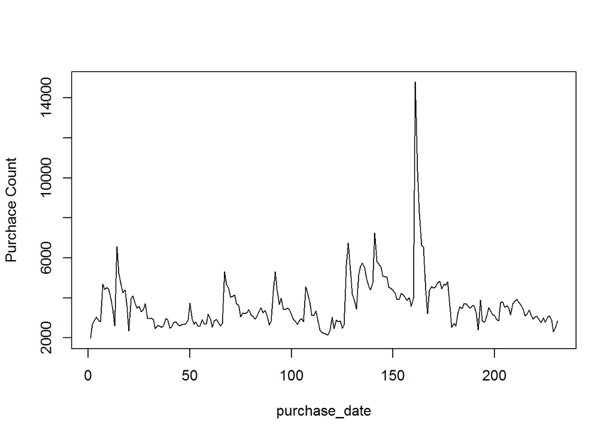

```r
plot(
  (userBrandsDF %>% group_by(purchase_date) %>% tally())$n,
  type="l",xlab="purchase_date", ylab="Purchace Count"
)
```

In this data there is a clear important and central point, the outlier with a very high value. In the initial analysis of the statistical moments, it was concluded that this was due to holidays. Combining this with the knowledge that this data likely stems largely from the USA (a heavily Christian country), It was concluded that this spike comes immediately after Christmas. A larger than normal amount is observed before this, which declines (due to the purchase Christmas gifts), followed by a spike and rapid decline (caused by after Christmas gift swapping and heavily discounted prices).

### Relations

With the combined knowledge obtained from the statistical tables and the set of univariate plots, the understanding of each individual variable is now very solid. However, there is still a quite large gap in the understanding of the dataset, regarding the relations between variable distributions. Similarly, to the analysis of single variable distributions, an initial analysis of statistical moments was performed, which was followed by a set of bivariate graphical plots.

#### Distribution by group

As mentioned, the first dual variable analysis entails the obtention of a statistical moment table, this time with the distributions being obtained split by the values of other variables. Due to the number of unique values, only 2 variables were split by their values, user_segment and perc_sale.

A second set of tables that is also obtained is the set contingency tables for platform, user_segment and perc_sale. Platform was here included, unlike for the statistics table, as the contingency table occupies less space, thus permitting the utilization of a variable with slightly more unique values.

```r
describeBy(userBrandsDF, userBrandsDF$perc_sale)
```

```
##
##  Descriptive statistics by group
## group: (0, 25]
##               vars     n        mean          sd   median     trimmed
## user_id*         1 91704         NaN          NA       NA         NaN
## brand_id         2 91704 51775886.64 29956092.56 50039784 52116569.85
## platform         3 91704 48430440.77 13669659.47 50298854 47596890.34
## country*         4 91704         NaN          NA       NA         NaN
## user_segment*    5 91704         NaN          NA       NA         NaN
## purchase_date    6 91704      136.87       55.69      151      142.93
## perc_sale*       7 91704         NaN          NA       NA         NaN
##                      mad      min      max    range  skew kurtosis       se
## user_id*              NA      Inf     -Inf     -Inf    NA       NA       NA
## brand_id      38608176.1   287368 99855154 99567786  0.01    -1.26 98921.58
## platform      15481043.8 15766995 82921252 67154257  0.45    -0.73 45140.21
## country*              NA      Inf     -Inf     -Inf    NA       NA       NA
## user_segment*         NA      Inf     -Inf     -Inf    NA       NA       NA
## purchase_date       34.1        1      231      230 -0.97     0.16     0.18
## perc_sale*            NA      Inf     -Inf     -Inf    NA       NA       NA
## ------------------------------------------------------------
## group: (25, 50]
##               vars      n        mean          sd   median     trimmed
## user_id*         1 321660         NaN          NA       NA         NaN
## brand_id         2 321660 51393299.65 28839280.88 49160230 51384848.70
## platform         3 321660 47585810.05 13656657.47 39857033 46573225.17
## country*         4 321660         NaN          NA       NA         NaN
## user_segment*    5 321660         NaN          NA       NA         NaN
## purchase_date    6 321660      124.33       66.93      143      127.29
## perc_sale*       7 321660         NaN          NA       NA         NaN
##                       mad      min      max    range  skew kurtosis       se
## user_id*               NA      Inf     -Inf     -Inf    NA       NA       NA
## brand_id      33605662.76   102532 99855154 99752622  0.08    -1.23 50849.41
## platform       6786156.72 15766995 82921252 67154257  0.57    -0.61 24079.41
## country*               NA      Inf     -Inf     -Inf    NA       NA       NA
## user_segment*          NA      Inf     -Inf     -Inf    NA       NA       NA
## purchase_date       66.72        1      231      230 -0.47    -1.05     0.12
## perc_sale*             NA      Inf     -Inf     -Inf    NA       NA       NA
## ------------------------------------------------------------
## group: (50, 75]
##               vars     n        mean          sd   median    trimmed
```

[output cut: 36 more lines]

```
## user_id*         1 383519         NaN          NA       NA         NaN
## brand_id         2 383519 53940412.92 28906400.07 51522426 54673053.97
## platform         3 383519 47080670.17 13414669.37 39857033 46212375.95
## country*         4 383519         NaN          NA       NA         NaN
## user_segment*    5 383519         NaN          NA       NA         NaN
## purchase_date    6 383519      111.61       62.06      105      109.84
## perc_sale*       7 383519        0.00        0.00        0        0.00
##                       mad      min      max    range  skew kurtosis       se
## user_id*               NA      Inf     -Inf     -Inf    NA       NA       NA
## brand_id      36410011.04   102532 99855154 99752622 -0.05    -1.26 46676.75
## platform       6786156.72 15766995 96462699 80695704  0.55    -0.69 21661.40
## country*               NA      Inf     -Inf     -Inf    NA       NA       NA
## user_segment*          NA      Inf     -Inf     -Inf    NA       NA       NA
## purchase_date       69.68        1      231      230  0.26    -0.94     0.10
## perc_sale*           0.00        0        0        0   NaN      NaN     0.00
```

```r
describeBy(userBrandsDF, userBrandsDF$user_segment)
```

```
##
##  Descriptive statistics by group
## group: segment_0
##               vars     n        mean          sd   median     trimmed
## user_id*         1 46523         NaN          NA       NA         NaN
## brand_id         2 46523 54863739.58 28752727.30 52029885 55716830.28
## platform         3 46523 44850103.80 13508129.43 35279833 43456710.19
## country*         4 46523         NaN          NA       NA         NaN
## user_segment*    5 46523         NaN          NA       NA         NaN
## purchase_date    6 46523       96.95       65.99       88       93.65
## perc_sale*       7 46523        0.00        0.00        0        0.00
##                       mad      min      max    range  skew kurtosis        se
## user_id*               NA      Inf     -Inf     -Inf    NA       NA        NA
## brand_id      37531618.70   102532 99855154 99752622 -0.09    -1.24 133304.62
## platform             0.00 15766995 82921252 67154257  0.93    -0.01  62626.96
## country*               NA      Inf     -Inf     -Inf    NA       NA        NA
## user_segment*          NA      Inf     -Inf     -Inf    NA       NA        NA
## purchase_date       84.51        1      231      230  0.31    -1.10      0.31
## perc_sale*           0.00        0        0        0   NaN      NaN      0.00
## ------------------------------------------------------------
## group: segment_1
##               vars      n        mean          sd   median    trimmed
## user_id*         1 355539         NaN          NA       NA        NaN
## brand_id         2 355539 52702464.62 29244060.11 51215738 53081995.2
## platform         3 355539 46729967.90 13489723.67 35279833 45625890.3
## country*         4 355539         NaN          NA       NA        NaN
## user_segment*    5 355539         NaN          NA       NA        NaN
## purchase_date    6 355539      118.29       65.22      128      119.2
## perc_sale*       7 355539        0.00        0.00        0        0.0
##                      mad      min      max    range  skew kurtosis       se
## user_id*              NA      Inf     -Inf     -Inf    NA       NA       NA
## brand_id      36507260.7   102532 99855154 99752622  0.01    -1.26 49044.92
## platform       6786156.7 15766995 82921252 67154257  0.67    -0.50 22623.48
## country*              NA      Inf     -Inf     -Inf    NA       NA       NA
## user_segment*         NA      Inf     -Inf     -Inf    NA       NA       NA
## purchase_date       77.1        1      231      230 -0.15    -1.15     0.11
## perc_sale*           0.0        0        0        0   NaN      NaN     0.00
## ------------------------------------------------------------
## group: segment_2
##               vars      n        mean          sd   median     trimmed
```

[output cut: 54 more lines]

```
## user_id*         1 42100         NaN          NA       NA         NaN
## brand_id         2 42100 52876175.86 28742864.84 51215738 53341463.56
## platform         3 42100 48106366.65 13275117.65 39857033 47633955.08
## country*         4 42100         NaN          NA       NA         NaN
## user_segment*    5 42100         NaN          NA       NA         NaN
## purchase_date    6 42100      125.85       62.79      133      127.93
## perc_sale*       7 42100        0.00        0.00        0        0.00
##                       mad      min      max    range  skew kurtosis        se
## user_id*               NA      Inf     -Inf     -Inf    NA       NA        NA
## brand_id      35628848.38   102532 99855154 99752622 -0.02    -1.26 140084.15
## platform      15481043.81 15766995 82921252 67154257  0.33    -0.93  64698.96
## country*               NA      Inf     -Inf     -Inf    NA       NA        NA
## user_segment*          NA      Inf     -Inf     -Inf    NA       NA        NA
## purchase_date       71.16        1      231      230 -0.26    -0.95      0.31
## perc_sale*           0.00        0        0        0   NaN      NaN      0.00
```

```r
table(userBrandsDF$platform, userBrandsDF$user_segment, userBrandsDF$perc_sale)
```

```
## , ,  = (0, 25]
##
##
##            segment_0 segment_1 segment_2 segment_3 segment_4 segment_5
##   15766995         2         8         1         3         2         0
##   22734142         2        26         4         2         3         0
##   24380949        55       200        72        47        60        33
##   34959346       107      1238       414       155       295        65
##   35279833      2005     17431      7139      3352      6522      1617
##   39857033        89      1955       937       536       991       263
##   47514527         0         0         0         0         0         0
##   50298854       150      1115       278        56       195        28
##   54454273        29       320        84        17        59        13
##   59713904      1194     16143      8401      4160      8071      2103
##   82921252       165      1656       736       314       657       129
```

[output cut: 69 more lines]

The 3 variable contingency table, however, presents far more meaningful results. the first one to point out is that platform 96462699 only appears 3 times and always for perc_sale of 0 and for segment_3. Platform 47514527 is also quite rare, appearing only in a handful of instances for segments 1 and 2, which are the most populated. Regardless, there does not appear to be any strong correlation amongst these 3 variables, with occurrences being mostly independent and only affected by the relative frequency of each value.

These results imply that the task might be very difficult and bad results would not be unexpected.

#### Correlation Heatmap

With the intent of further investigating variable correlation, a correlation heatmap was created. Upon its investigation is obvious that no variable has high correlation with another, and as such, to improve the chances at obtaining good results, heavily nonlinear approaches are likely to be required.

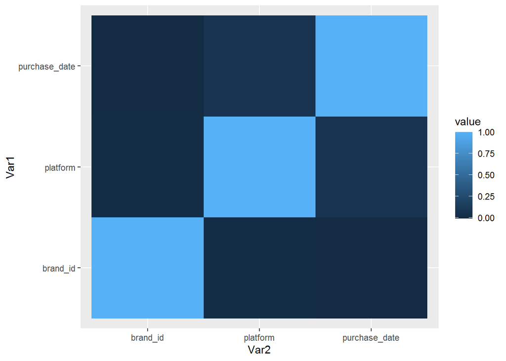

```r
userBrandsDFNum = userBrandsDF[, sapply(userBrandsDF, is.numeric)]
corMatrix = round(cor(userBrandsDFNum),2)
corMap = melt(corMatrix)
ggplot(data = corMap, aes(x=Var2, y=Var1, fill=value)) + geom_tile()
```

#### Grouped Box Plots

In a final effort to identify strong variable relations box plots split by class were created. To make these plots understandable the values were only divided by the 3 variables with the least number of unique variables: platform, user_segment and perc_sale.

For the two plots regarding brand_id and purchace_date divided by platform, the 2 most interesting cases, platforms 47514527 and 96462699 can be ruled out, as these were the ones identified as almost nonexistent. The case for 22734142 is, however, more relevant as this class has enough occurrences for this to be considered a real relation with purchace_date. Other cases, however, do not present enough variation to be considered relevant.

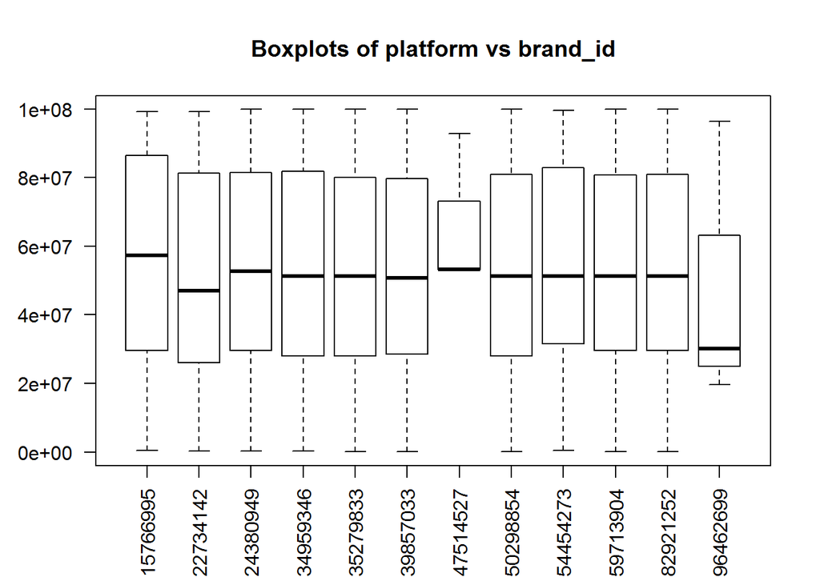

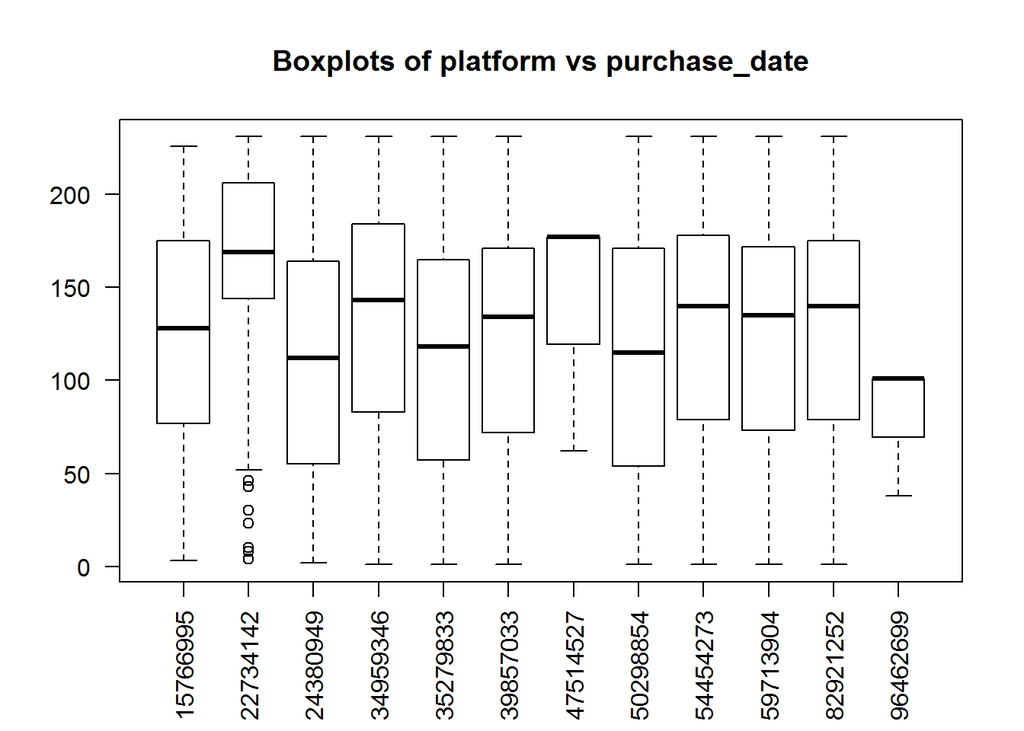

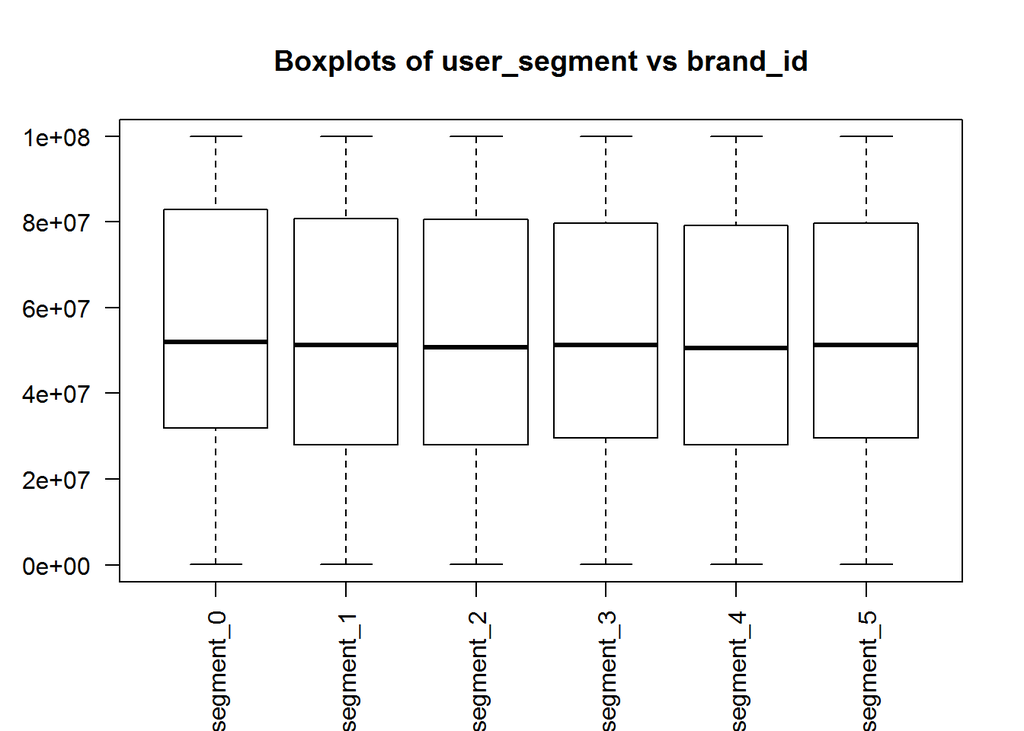

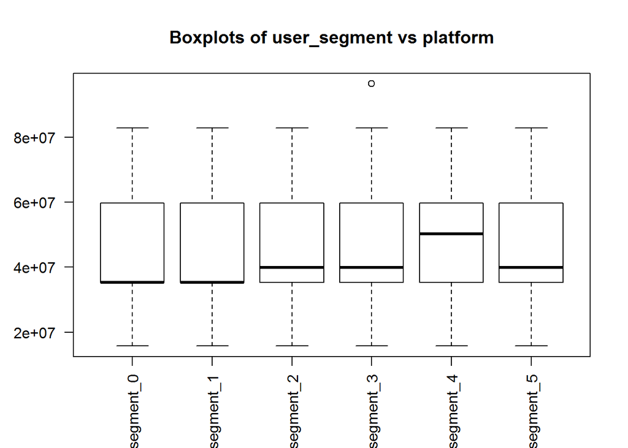

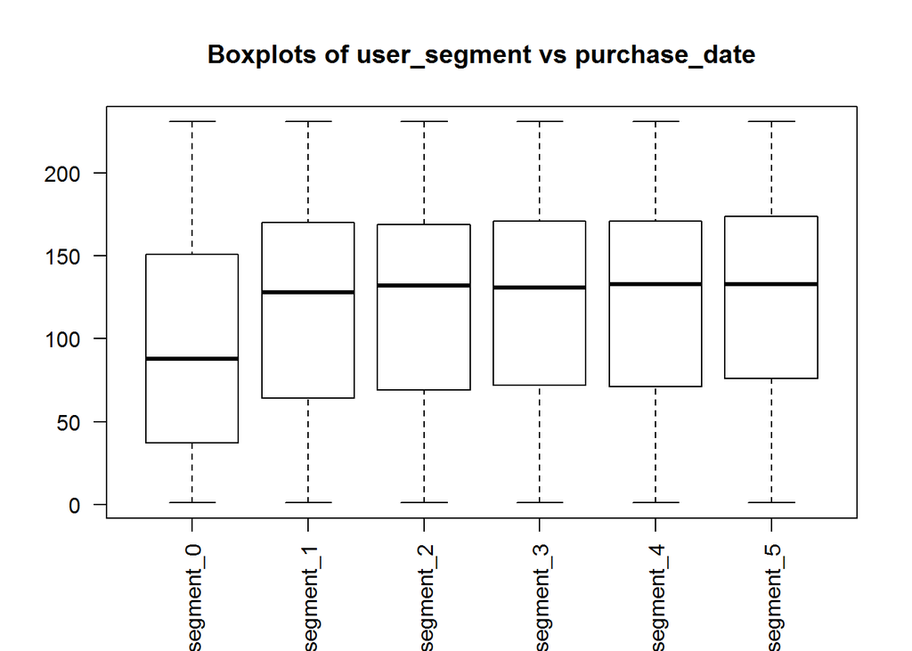

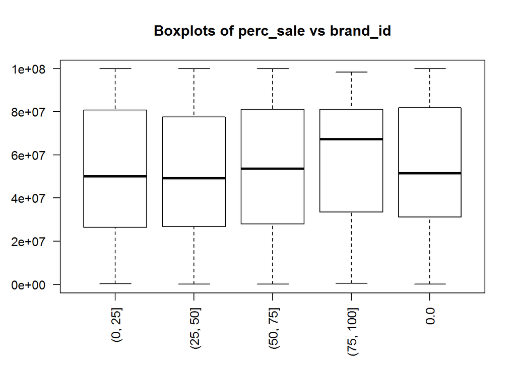

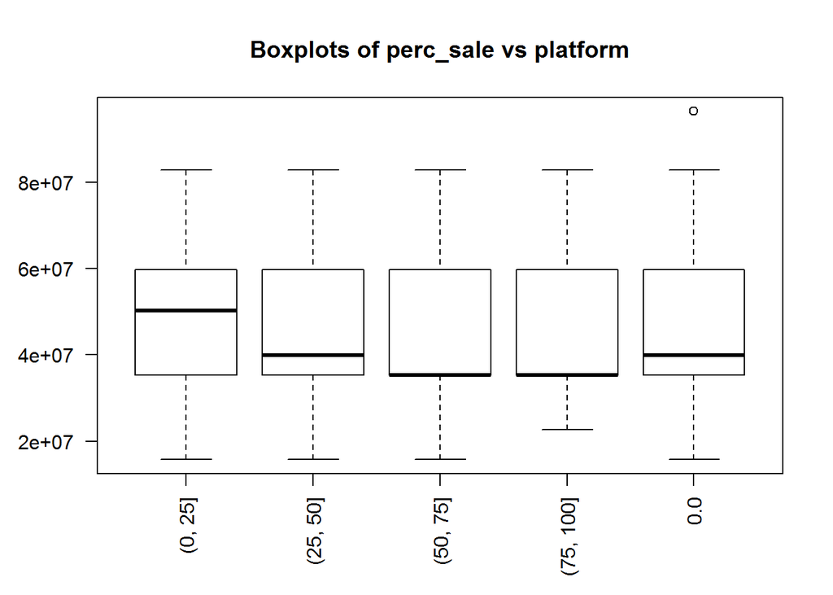

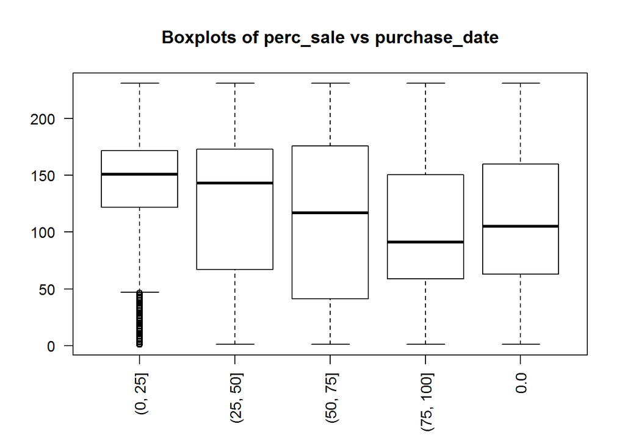

```r
for (column1 in c("platform","user_segment","perc_sale")){
  for (column2 in names(userBrandsDF)){
    if (column1==column2){
      next()
    }
    tryCatch(
      {
        boxplot(
          userBrandsDF[,column2] ~ userBrandsDF[,column1],
          main=paste("Boxplots of",column1,"vs",column2),
          las=2, ylab="", xlab=""
        )

      },
      error = function(e) {}
    )
  }
}
```